# Purple Sea Urchins in Naples, 2010

Margaret Hammond

10/27/2021

## Overview

Sea urchin populations in 5 different reefs in Santa Barbara: Naples Reef, Arroyo Quemado Reef, Carpinteria Reef, Mohawk Reef, and Isla Vista Reef. This data holds information on the size frequency distribution of red and purple sea urchins from 2008 - 2020. The data is analyzed to determine a relationship between treatment and size of purple sea urchins in Naples Reef during 2010. The treatment consisted of removing the giant kelp species in the area, the control being that no kelp was removed.

## Citation

Reed, D. 2020. SBC LTER: Reef: Long-term experiment: Kelp removal: Urchin size frequency distribution ver 20. Environmental Data Initiative. https://doi.org/10.6073/pasta/5a1e9ef03aa47bd2225c0bb98a02a63b.

```r
knitr::opts_chunk$set(echo = TRUE)

library(tidyverse)
library(kableExtra)
library(here)
library(janitor)
library(lubridate)
```

## Read in Data

```r
urchins <- read_csv(here("data", "urchins.csv"))
urchins_tidy <- urchins %>% clean_names()
```

## Wrangle Data

Wrangle the data to only include Naples Reef observations for purple urchins observed in 2010.

```r
naples_urchin <- urchins_tidy %>%
  filter(common_name == "Purple Urchin",
         site == "NAPL") %>% # Filter to create data only containing purple urchins at Naples
  mutate(date = mdy(date)) %>% # Use mdy() to convert to Date class
  mutate(year = year(date)) %>%
  filter(year == "2010") %>% # Filter again to only hold 2010 data
  mutate(treatment = case_when(
    treatment == "ANNUAL" ~ "Annual", # Change data values for easier organization
    treatment == "CONTROL" ~ "Control"))
```

## Visualize the Data

Histogram of purple urchins at Naples in 2010, as shown by their specific treatment. This is to visualize the data and understand the relationship of treatment on size.

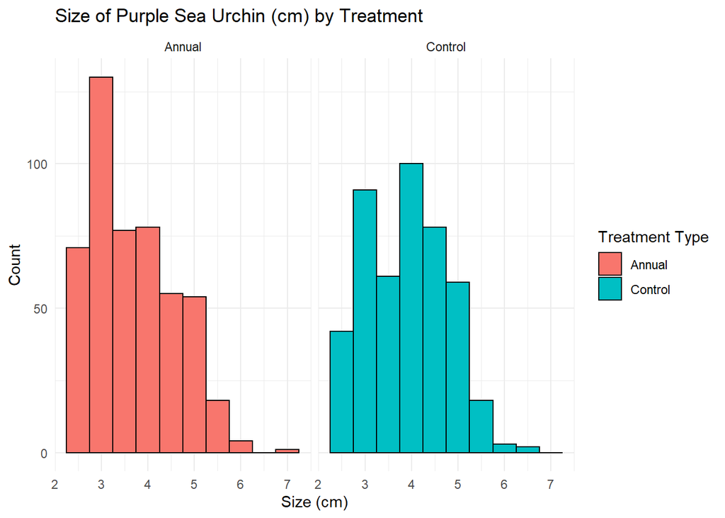

```r
ggplot(data = naples_urchin, aes(x = size)) +
  geom_histogram(bins = 10, # Create histogram to visualize data spread
                 color = "black",
                 aes(fill = treatment)) +
  facet_wrap(~ treatment) +
  labs(x = "Size (cm)",
       y = "Count",
       title = "Size of Purple Sea Urchin (cm) by Treatment",
       fill = "Treatment Type") +
  theme_minimal()
```

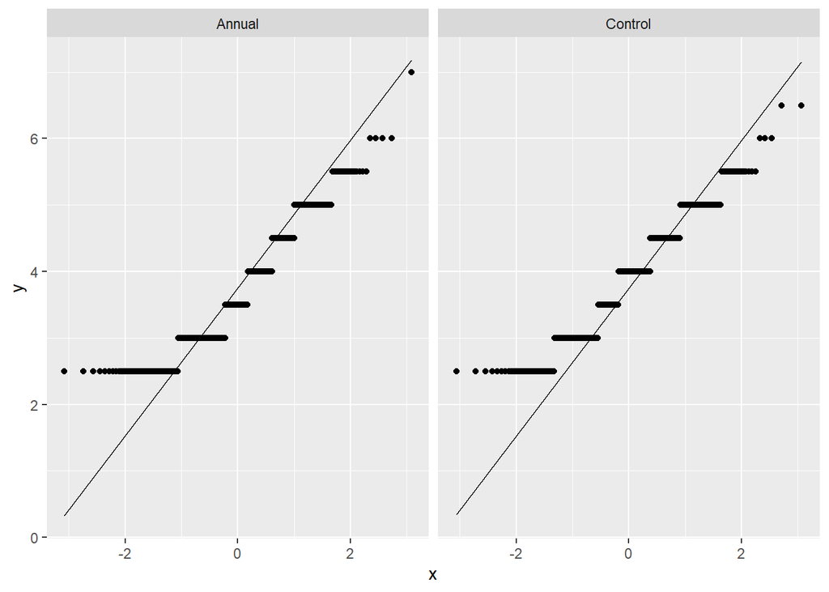

```r
ggplot(data = naples_urchin, aes(sample = size)) +
  stat_qq() +
  geom_qq_line() +
  facet_wrap(~treatment)
```

## Summary Table

Summary table of the relationship of treatment to size on purple sea urchins at Naples Reef during the year 2010. This table holds information on the mean, median, standard deviation, and sample size.

```r
treatment_urchin <- naples_urchin %>%
  group_by(treatment) %>% # Group by treatment to compare control vs. treatment
  summarize(mean_size_cm = round(mean(size), 2), # Round to the 2 decimal places for organization
            median_size_cm = median(size),
            sd_size_cm = round(sd(size), 2), # Round to the 2 decimal places for organization
            sample_size = n())

treatment_urchin %>%
  kable(col.names = c("Treatment",
                      "Mean size (cm)",
                      "Median size (cm)",
                      "Standard deviation (cm)",
                      "Sample size (n)"),
        caption = "Figure 1. Purple Sea Urchin Size (cm) by Treatment on Naples Reef, 2010") %>%
  kable_styling(full_width = TRUE)
```

Figure 1. Purple Sea Urchin Size (cm) by Treatment on Naples Reef, 2010

| Treatment | Mean size (cm) | Median size (cm) | Standard deviation (cm) | Sample size (n) |
| --- | --- | --- | --- | --- |
| Annual | 3.68 | 3.5 | 0.90 | 488 |
| Control | 3.89 | 4.0 | 0.87 | 454 |

### End of Task 4